# 12 Supplementary figures

This chapter regenerates the supplementary figures of the manuscript from the saved data objects (`data/data.Rdata`), the GUNC summary (`data/gunc_summary.tsv`) and the runtime tables (`data/runtime/`). Figures are numbered in the order in which the manuscript cites them and written to `figures/supplementary/` (300 dpi PNG and vector PDF).

| Supplementary figure | Content | Chunk it was reproduced from |
| --- | --- | --- |
| S1 | Cluster abundance versus number of strategies recovering the cluster | `read_count_vs_frequency` (chapter 2; previous S1 and S6, which were the same plot) |
| S2 | Cluster abundances across samples, grouped by time point | `read_abundances_timepoint` (chapter 2) |
| S3 | CheckM2 completeness and contamination of all bins | `bin_quality_biplot` (chapter 3) |
| S4 | GUNC outcome of the bins of each strategy (new; the manuscript quotes the pass rates) | `GUNC` (chapter 3) |
| S5 | KEGG module fullness of the clusters | `function_overview_heatmap` (chapter 4) |
| S6 | Cluster abundances ordered by rank, per strategy | new (no code existed for the previous S5) |
| S7 | Computational time per strategy and estimates for other designs | chapter 9 |

```r
library(tidyverse)
library(ape)
library(phytools)
library(ggtree)
library(ggh4x)
library(patchwork)
library(tinytable)

load("data/data.Rdata")

dir.create("figures/supplementary", recursive = TRUE, showWarnings = FALSE)
supp_w <- 180   # mm, fits the text width of a portrait page with 15 mm margins

# Helvetica if the system has it, otherwise Arial, otherwise the default sans (as in chapter 11)
supp_font <- local({
  for (f in c("Helvetica", "Arial")) if (grepl(f, basename(systemfonts::match_fonts(f)$path), ignore.case = TRUE)) return(f)
  "sans"
})

theme_supp <- function() {
  theme_classic(base_size = 8, base_family = supp_font) +
    theme(axis.text = element_text(colour = "grey10"),
          axis.title = element_text(colour = "black"),
          legend.key.size = unit(3.5, "mm"),
          strip.background = element_rect(fill = "grey90", colour = NA),
          plot.tag = element_text(face = "bold", size = 10, family = supp_font))
}

save_supp <- function(plot, name, height_mm, width_mm = supp_w) {
  ggsave(paste0("figures/supplementary/", name, ".png"), plot, width = width_mm, height = height_mm, units = "mm", dpi = 300, bg = "white")
  ggsave(paste0("figures/supplementary/", name, ".pdf"), plot, width = width_mm, height = height_mm, units = "mm", device = cairo_pdf)
}

# Phylum colours (EHI scheme, as in chapter 11); clusters without taxonomy stay grey
phylum_names <- cluster_taxonomy %>% filter(!is.na(Phylum)) %>% pull(Phylum) %>% unique() %>% sort()
stopifnot(length(phylum_names) == length(phylum_colors))
phylum_pal <- c(setNames(phylum_colors, phylum_names), `No taxonomy` = "#BDBDBD")

cluster_phylum <- tibble(secondary_cluster = unique(bin_metadata$secondary_cluster)) %>%
  left_join(cluster_taxonomy %>% select(secondary_cluster, Phylum) %>% distinct(), by = "secondary_cluster") %>%
  mutate(Phylum = replace_na(Phylum, "No taxonomy"))

# Number of strategies in which each cluster was recovered (all MAGs, as in Figure 2 and the text)
cluster_n_strategy <- bin_metadata %>% distinct(secondary_cluster, overall_strategy) %>% count(secondary_cluster, name = "n_strategy")

# Bioinformatic approach of each strategy
approach_levels <- c("Single-coverage", "Multi-coverage", "Co-assembly", "Multi-split")
strategy_approach <- tibble(strategy = strategies) %>%
  mutate(approach = factor(case_when(str_starts(strategy, "single") ~ "Single-coverage",
                                     str_starts(strategy, "multicoverage") ~ "Multi-coverage",
                                     str_starts(strategy, "coassembly") ~ "Co-assembly",
                                     str_starts(strategy, "multisplit") ~ "Multi-split"), levels = approach_levels))
```

## 12.1 Figure S1: cluster abundance and strategy prevalence

```r
s1_data <- cluster_counts %>%
  summarise(abundance = max(read_count), .by = secondary_cluster) %>%
  inner_join(cluster_n_strategy, by = "secondary_cluster") %>%
  left_join(cluster_phylum, by = "secondary_cluster")

cat("Clusters shown (n):", nrow(s1_data), "of", n_distinct(bin_metadata$secondary_cluster), "in the catalogue; the rest received no reads in any strategy\n")
```

```
Clusters shown (n): 217 of 235 in the catalogue; the rest received no reads in any strategy
```

```r
s1_cor <- cor.test(s1_data$abundance, s1_data$n_strategy, method = "spearman", exact = FALSE)
s1_cor
```

```
    Spearman's rank correlation rho

data:  s1_data$abundance and s1_data$n_strategy
S = 197485, p-value < 2.2e-16
alternative hypothesis: true rho is not equal to 0
sample estimates:
      rho
0.8840381
```

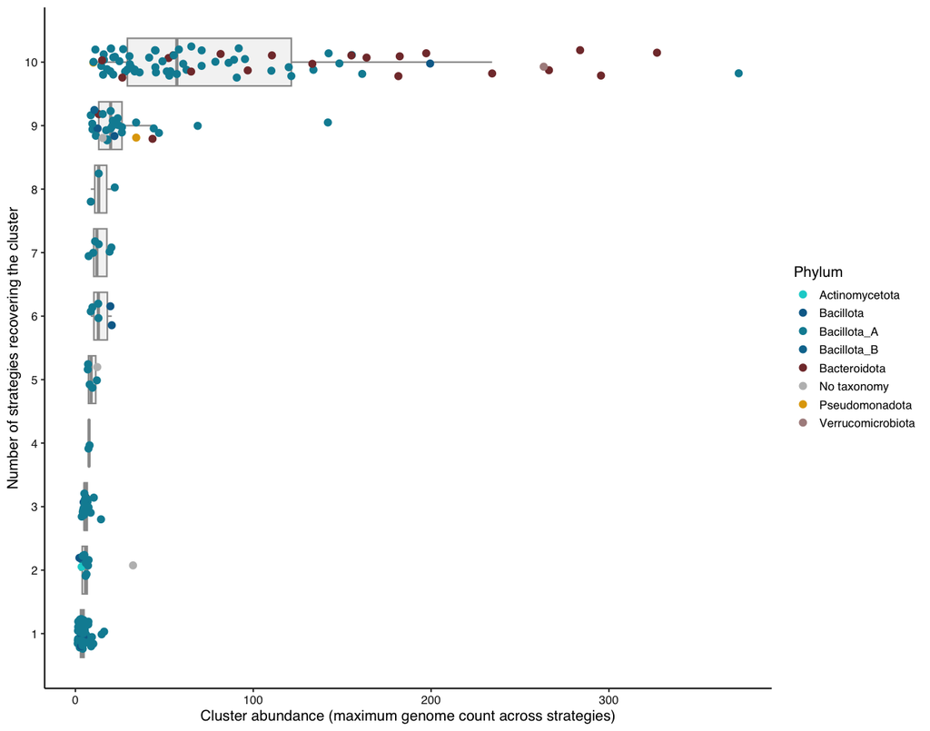

```r
fig_s1 <- ggplot(s1_data, aes(x = abundance, y = n_strategy, group = n_strategy)) +
  geom_boxplot(colour = "#999999", fill = "#f4f4f4", outlier.shape = NA, linewidth = 0.4) +
  geom_point(aes(colour = Phylum), size = 1.4, position = position_jitter(width = 0, height = 0.25, seed = 1)) +
  scale_y_continuous(breaks = 1:10) +
  scale_colour_manual(values = phylum_pal) +
  labs(x = "Cluster abundance (maximum genome count across strategies)", y = "Number of strategies recovering the cluster") +
  theme_supp()
fig_s1
```

```r
save_supp(fig_s1, "FigureS1", 105)
```

## 12.2 Figure S2: cluster abundances across samples and time points

For every sample and cluster the highest genome count among the ten strategies is shown, so that a cluster that only some strategies recovered is displayed wherever it was recovered. Clusters follow the phylogeny, samples are grouped by sampling time point (T1-T5) and ordered by cage and animal. The colour scale is square-root transformed because a few clusters dominate the communities.

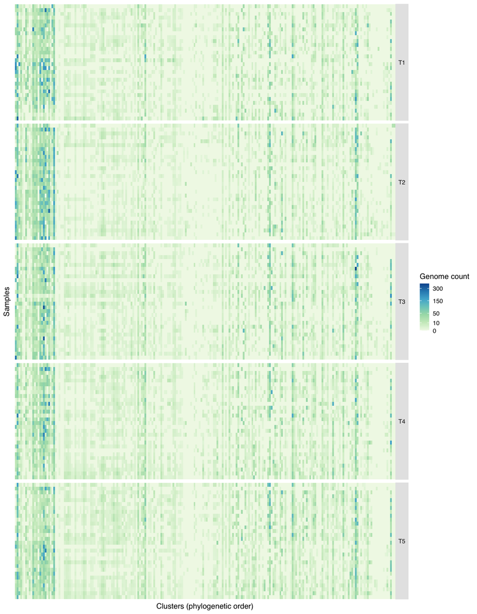

```r
timepoints <- c("OP", "HT", "HR", "CT", "CR")   # sample-name codes, shown as T1-T5

s2_data <- bin_counts_norm_filt %>%
  filter(!is.na(overall_strategy)) %>%
  summarise(count = sum(read_count), .by = c(sample, secondary_cluster, overall_strategy)) %>%
  summarise(abundance = max(count), .by = c(sample, secondary_cluster)) %>%
  mutate(timepoint = factor(substr(sample, 6, 7), levels = timepoints, labels = paste0("T", seq_along(timepoints))),
         secondary_cluster = factor(secondary_cluster, levels = cluster_tree$tip.label)) %>%
  filter(!is.na(secondary_cluster)) %>%
  mutate(sample = factor(sample, levels = sort(unique(sample))))
stopifnot(!anyNA(s2_data$timepoint))

fig_s2 <- ggplot(s2_data, aes(x = secondary_cluster, y = sample, fill = abundance)) +
  geom_tile() +
  scale_fill_distiller(palette = "GnBu", direction = 1, transform = "sqrt", breaks = c(0, 10, 50, 150, 300)) +
  facet_grid(timepoint ~ ., scales = "free_y", space = "free_y") +
  labs(x = "Clusters (phylogenetic order)", y = "Samples", fill = "Genome count") +
  theme_supp() +
  theme(axis.text = element_blank(), axis.ticks = element_blank(), axis.line = element_blank(),
        strip.text.y = element_text(angle = 0), panel.spacing.y = unit(1, "mm"))
fig_s2
```

```r
save_supp(fig_s2, "FigureS2", 200)
```

## 12.3 Figure S3: CheckM2 completeness and contamination of all bins

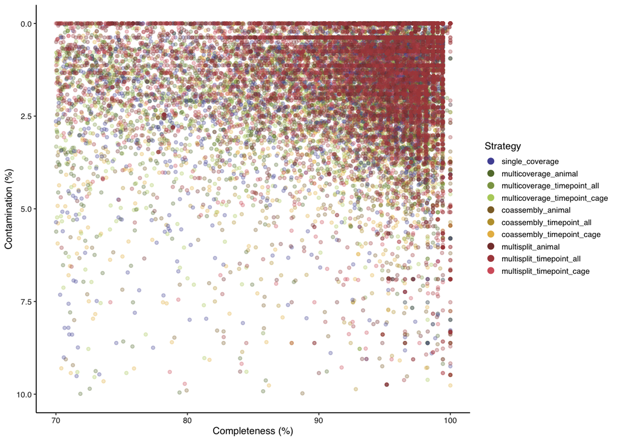

```r
fig_s3 <- bin_metadata %>%
  mutate(overall_strategy = factor(overall_strategy, levels = strategies)) %>%
  ggplot(aes(x = completeness, y = contamination, colour = overall_strategy)) +
  geom_point(alpha = 0.3, size = 1) +
  scale_colour_manual(values = strategy_colors) +
  scale_y_reverse(limits = c(10, 0)) +
  guides(colour = guide_legend(override.aes = list(alpha = 1, size = 2))) +
  labs(x = "Completeness (%)", y = "Contamination (%)", colour = "Strategy") +
  theme_supp()
fig_s3
```

```r
save_supp(fig_s3, "FigureS3", 100)
```

## 12.4 Figure S4: GUNC outcome per strategy

GUNC was run on the dereplicated bins of each strategy. The percentage above each bar is the share of bins passing GUNC.

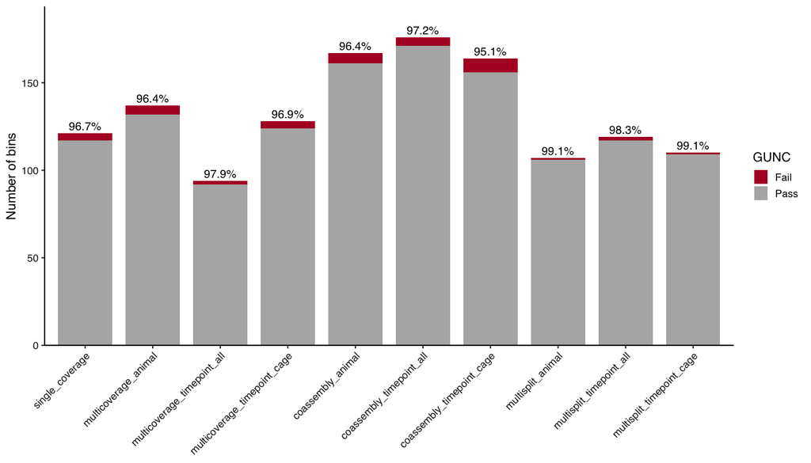

```r
gunc <- read_delim("data/gunc_summary.tsv", show_col_types = FALSE) %>%
  mutate(overall_strategy = factor(overall_strategy, levels = strategies),
         GUNC = factor(ifelse(pass.GUNC, "Pass", "Fail"), levels = c("Fail", "Pass")))

gunc_rate <- gunc %>%
  summarise(n = n(), passed = sum(pass.GUNC), .by = overall_strategy) %>%
  mutate(percent = passed / n * 100)

fig_s4 <- ggplot(gunc, aes(x = overall_strategy, fill = GUNC)) +
  geom_bar(width = 0.8) +
  geom_text(data = gunc_rate, aes(x = overall_strategy, y = n, label = sprintf("%.1f%%", percent)),
            inherit.aes = FALSE, vjust = -0.4, size = 2.5, family = supp_font) +
  scale_fill_manual(values = c(Pass = "grey70", Fail = "#B2182B")) +
  scale_y_continuous(expand = expansion(mult = c(0, 0.1))) +
  labs(x = NULL, y = "Number of bins", fill = "GUNC") +
  theme_supp() +
  theme(axis.text.x = element_text(angle = 45, hjust = 1))
fig_s4
```

```r
save_supp(fig_s4, "FigureS4", 90)

gunc_rate %>% arrange(overall_strategy) %>% mutate(percent = round(percent, 1)) %>% tt()
```

| overall_strategy | n | passed | percent |
| --- | --- | --- | --- |
| single_coverage | 121 | 117 | 96.7 |
| multicoverage_animal | 137 | 132 | 96.4 |
| multicoverage_timepoint_all | 94 | 92 | 97.9 |
| multicoverage_timepoint_cage | 128 | 124 | 96.9 |
| coassembly_animal | 167 | 161 | 96.4 |
| coassembly_timepoint_all | 176 | 171 | 97.2 |
| coassembly_timepoint_cage | 164 | 156 | 95.1 |
| multisplit_animal | 107 | 106 | 99.1 |
| multisplit_timepoint_all | 119 | 117 | 98.3 |
| multisplit_timepoint_cage | 110 | 109 | 99.1 |

## 12.5 Figure S5: KEGG module fullness of the genome clusters

```r
cluster_kegg_max <- cluster_kegg %>%
  filter(!is.na(secondary_cluster)) %>%
  ungroup() %>%
  select(-overall_strategy) %>%
  group_by(secondary_cluster) %>%
  summarise(across(everything(), ~ max(.x, na.rm = TRUE)))

s5_phylum <- cluster_phylum %>%
  filter(secondary_cluster %in% cluster_tree$tip.label, secondary_cluster %in% cluster_kegg_max$secondary_cluster) %>%
  arrange(match(secondary_cluster, cluster_tree$tip.label)) %>%
  mutate(Phylum = factor(Phylum, levels = unique(Phylum))) %>%
  column_to_rownames("secondary_cluster")

s5_tree <- force.ultrametric(keep.tip(cluster_tree, rownames(s5_phylum)), method = "extend")
```

```
*                          Note:                              *
*    force.ultrametric does not include a formal method to    *
*    ultrametricize a tree & should only be used to coerce    *
*   a phylogeny that fails is.ultrametric due to rounding --  *
*    not as a substitute for formal rate-smoothing methods.   *
```

```r
s5_table <- cluster_kegg_max %>% filter(secondary_cluster %in% s5_tree$tip.label)
nrow(s5_table); ncol(s5_table) - 1
```

```
[1] 217
```

```
[1] 380
```

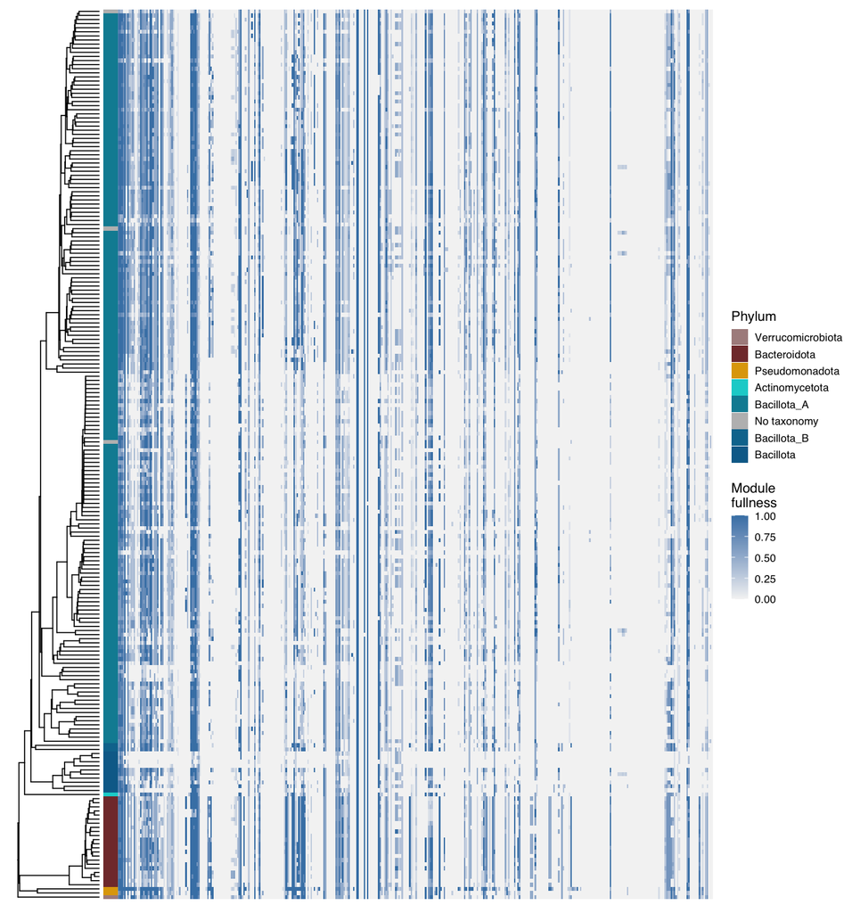

```r
# Row order is that of the tree; the three plots share it and are aligned by fixing the limits of the vertical axis
tree_plot <- ggtree(s5_tree, size = 0.3)
row_order <- tree_plot$data %>% filter(isTip) %>% arrange(desc(y)) %>% pull(label)   # top to bottom
n_rows <- length(row_order)

p_tree <- tree_plot + scale_y_continuous(limits = c(0.5, n_rows + 0.5), expand = c(0, 0)) + theme(plot.margin = margin(0, 0, 0, 0))

p_phylum <- s5_phylum %>% rownames_to_column("secondary_cluster") %>%
  mutate(secondary_cluster = factor(secondary_cluster, levels = rev(row_order))) %>%
  ggplot(aes(x = 1, y = secondary_cluster, fill = Phylum)) +
  geom_tile() +
  scale_fill_manual(values = phylum_pal) +
  scale_x_continuous(expand = c(0, 0)) + scale_y_discrete(expand = c(0, 0)) +
  theme_void(base_family = supp_font, base_size = 8) + theme(legend.key.size = unit(3.5, "mm"))

p_kegg <- s5_table %>%
  pivot_longer(-secondary_cluster, names_to = "module", values_to = "fullness") %>%
  mutate(secondary_cluster = factor(secondary_cluster, levels = rev(row_order)),
         module = factor(module, levels = setdiff(colnames(s5_table), "secondary_cluster"))) %>%
  ggplot(aes(x = module, y = secondary_cluster, fill = fullness)) +
  geom_tile() +
  scale_fill_gradient(low = "#f4f4f4", high = "steelblue", na.value = "white", limits = c(0, 1)) +
  scale_x_discrete(expand = c(0, 0)) + scale_y_discrete(expand = c(0, 0)) +
  labs(fill = "Module\nfullness") +
  theme_void(base_family = supp_font, base_size = 8) + theme(legend.key.size = unit(3.5, "mm"))

fig_s5 <- p_tree + p_phylum + p_kegg + plot_layout(widths = c(1.2, 0.2, 8), guides = "collect")
fig_s5
```

```r
save_supp(fig_s5, "FigureS5", 170)
```

## 12.6 Figure S6: cluster abundances per strategy

Clusters are ordered by their maximum genome count across strategies (as in Figure S1); gaps are clusters that the strategy did not recover.

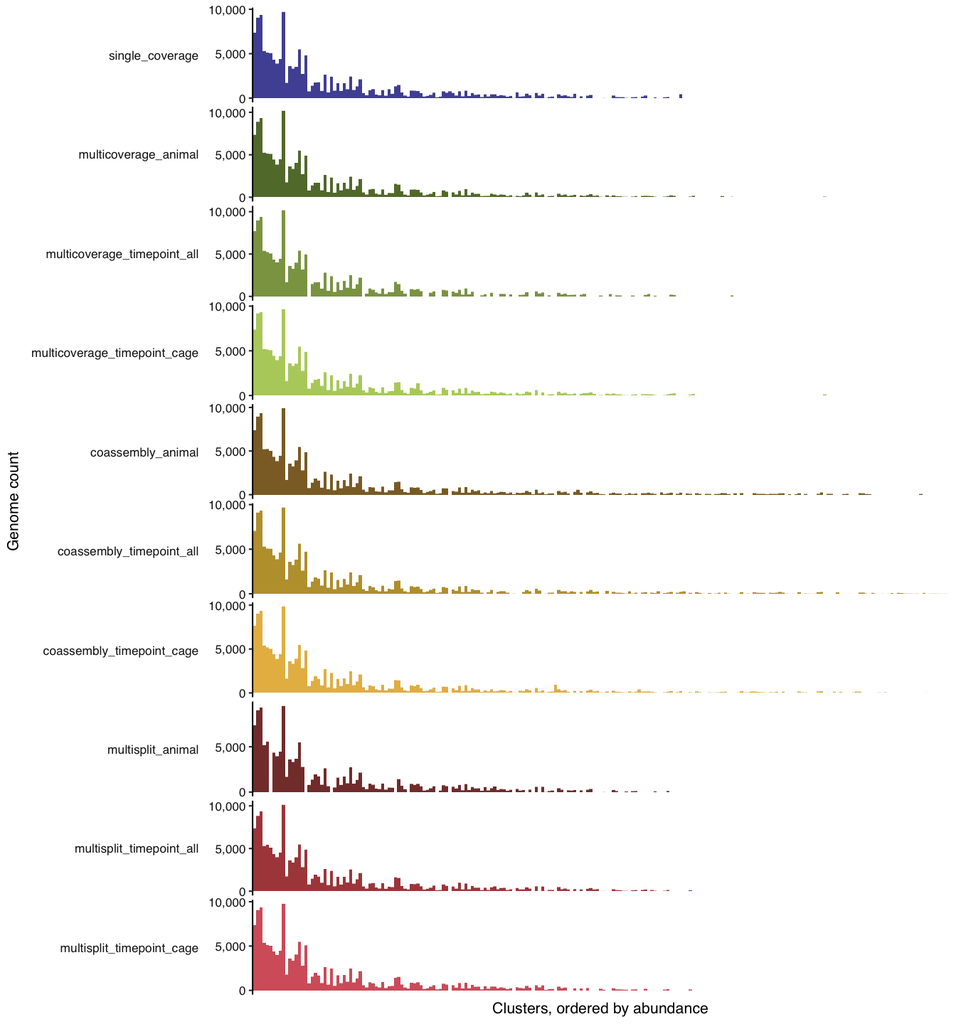

```r
cluster_order <- cluster_counts %>%
  summarise(abundance = max(read_count), .by = secondary_cluster) %>%
  arrange(desc(abundance)) %>%
  pull(secondary_cluster)

s6_data <- cluster_counts %>%
  complete(secondary_cluster, overall_strategy, fill = list(read_count = 0)) %>%
  mutate(secondary_cluster = factor(secondary_cluster, levels = cluster_order),
         overall_strategy = factor(overall_strategy, levels = strategies))

fig_s6 <- ggplot(s6_data, aes(x = secondary_cluster, y = read_count, fill = overall_strategy)) +
  geom_col(width = 1) +
  scale_fill_manual(values = strategy_colors, guide = "none") +
  facet_grid(overall_strategy ~ ., scales = "free_y", switch = "y") +
  scale_y_continuous(breaks = c(0, 5000, 10000), labels = scales::comma) +
  labs(x = "Clusters, ordered by abundance", y = "Genome count") +
  theme_supp() +
  theme(axis.text.x = element_blank(), axis.ticks.x = element_blank(), axis.line.x = element_blank(),
        strip.placement = "outside", strip.text.y.left = element_text(angle = 0, hjust = 1, size = 6.5),
        strip.background = element_blank(), panel.spacing.y = unit(0.8, "mm"))
fig_s6
```

```r
save_supp(fig_s6, "FigureS6", 170)
```

## 12.7 Figure S7: computational time

The data import and panels of chapter 9 are reused as they are; the code of that chapter is run here and its panels are tagged (a: total time per strategy and job; b: estimated time for other numbers of samples and groups).

```r
runtime_env <- new.env()
options(knitr.duplicate.label = "allow")  # chapter 9 chunk labels are already in use when the book is knitted
sys.source(knitr::purl("09_comp_resources.Rmd", output = tempfile(fileext = ".R"), quiet = TRUE), envir = runtime_env)
```

```
Scaling exponent of the mapping time per sample (alpha): 0.617
```

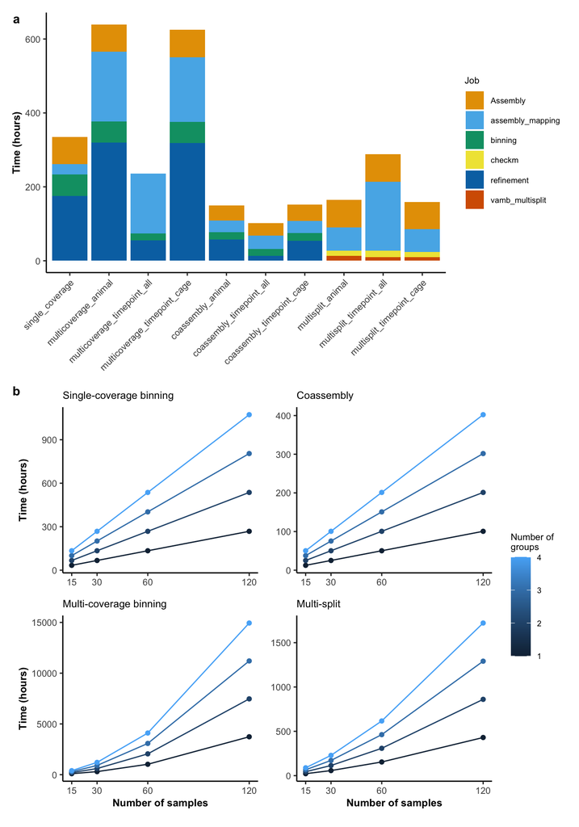

```r
# Sizes of chapter 9 (14 pt text for a 12 inch wide figure) reduced for a page-wide figure, and strategy names as in the manuscript
small <- theme(axis.text = element_text(size = 8), axis.text.x = element_text(size = 8), axis.text.y = element_text(size = 8), axis.title = element_text(size = 9, face = "bold"),
               plot.title = element_text(size = 9), legend.text = element_text(size = 7), legend.title = element_text(size = 8))
manuscript_name <- function(x) str_replace_all(x, c("single-coverage" = "single_coverage", "multi-coverage" = "multicoverage", "multi-split" = "multisplit"))
strategy_limits <- c("single-coverage", "multi-coverage_animal", "multi-coverage_timepoint_all", "multi-coverage_timepoint_cage",
                     "coassembly_animal", "coassembly_timepoint_all", "coassembly_timepoint_cage",
                     "multi-split_animal", "multi-split_timepoint_all", "multi-split_timepoint_cage")

fig_s7 <- with(runtime_env, {
  panel_a <- fig_a + scale_x_discrete(limits = strategy_limits, labels = manuscript_name) + labs(fill = "Job") + small
  panel_b <- (fig_b + fig_c + fig_d + fig_e) + plot_layout(guides = "collect") & small & labs(colour = "Number of\ngroups")
  wrap_elements(full = panel_a) / wrap_elements(full = panel_b) +
    plot_layout(heights = c(1, 1.2)) +
    plot_annotation(tag_levels = "a") & theme(plot.tag = element_text(face = "bold", size = 11))
})
fig_s7
```

```r
save_supp(fig_s7, "FigureS7", 220)
```

Eisenhofer, Raphael, Antton Alberdi, and Ben Woodcroft. 2024. “Large-Scale Estimation of Bacterial and Archaeal DNA Prevalence in Metagenomes Reveals Biome-Specific Patterns.” *bioRxiv*. https://doi.org/10.1101/2024.05.16.594470.

Eisenhofer, Raphael, Ostaizka Odriozola, and Antton Alberdi. 2023. “Impact of Microbial Genome Completeness on Metagenomic Functional Inference.” *ISME Communications* 3: 12.